# Smart Device Usage Analysis For Bellabeat

Isha Dubey

3/21/2022

## —————————————————————————————–

### RELATION B/W THE STEPS AND DISTANCE TRACKED BY THE DEVICE

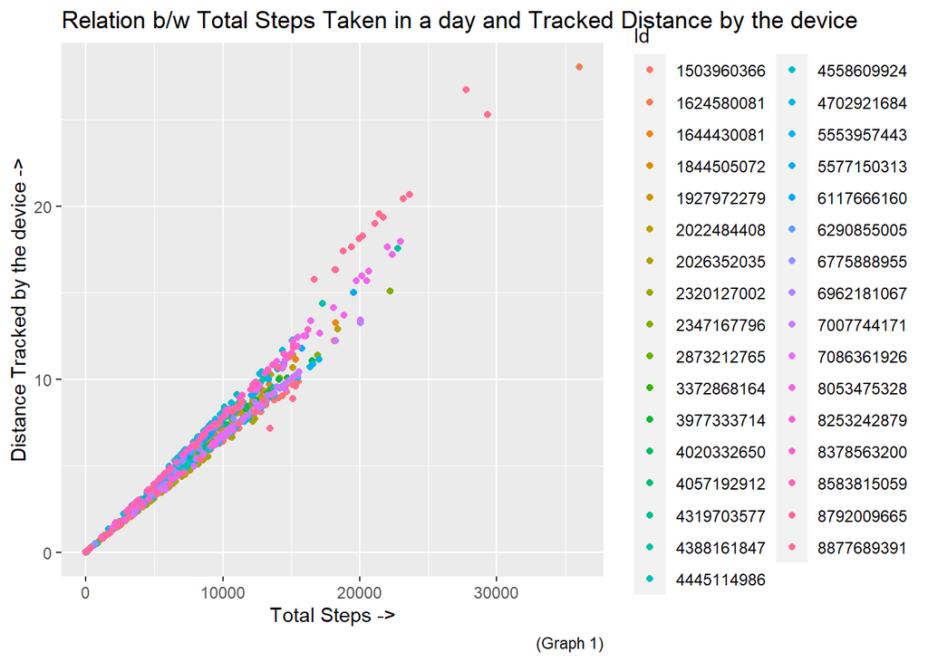

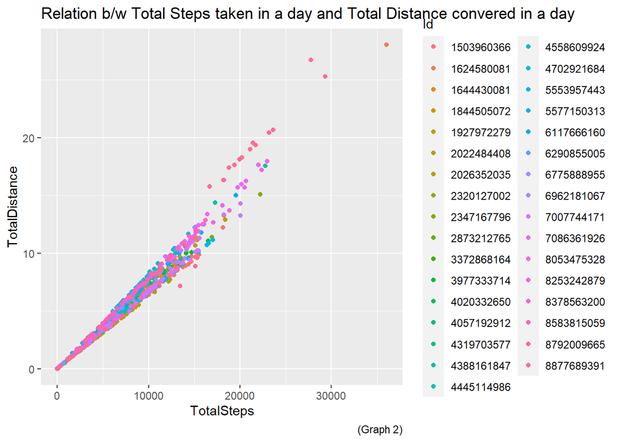

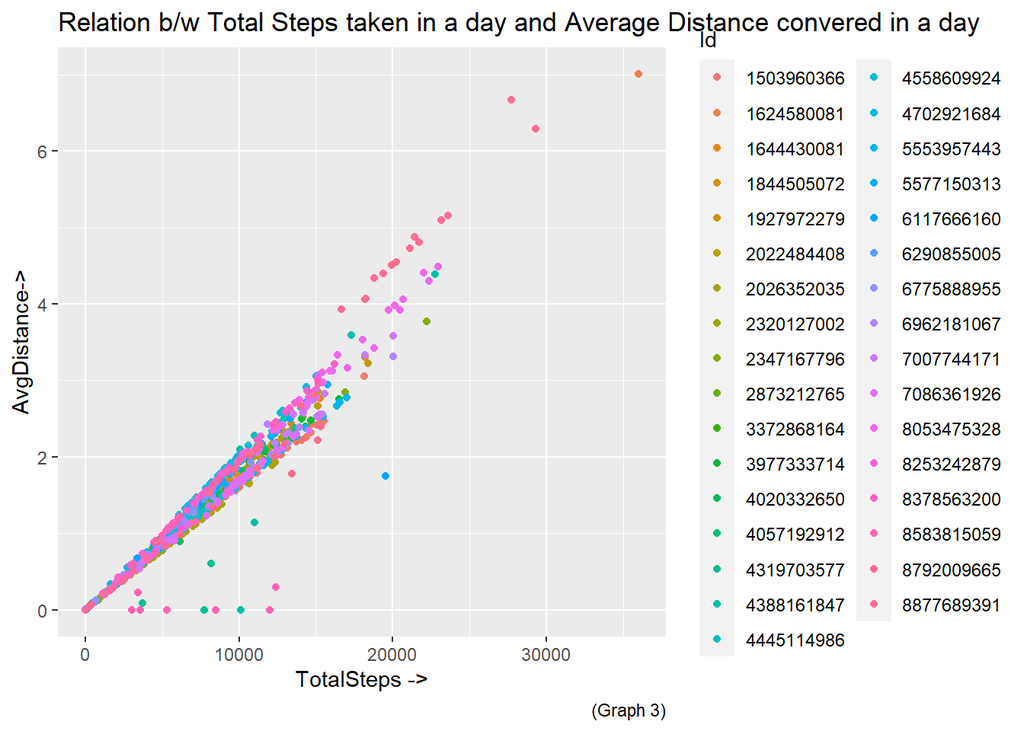

#### **CONCLUSION FROM GRAPH 1, GRAPH 2 AND GRAPH 3**

- The Relationship between steps and distance is linear.
- Distance is increasing with the steps.
- The Average disance is the average of the following distances :
  - Very Active
  - Moderately Active
  - Lightly Active

## —————————————————————————————–

### RELATION BETWEEN THE STEPS TAKEN AND CALORIES BURNT

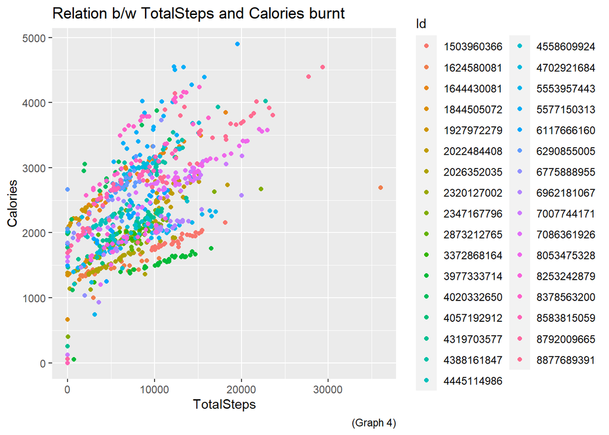

#### **CONCLUSION FROM GRAPH 4**

- The Relationship between steps and calories shows the increasing trend.
- More calories are burnt as the steps increase.

## —————————————————————————————–

### RELATION BETWEEN THE STEPS TAKEN AND ACTIVITY MINUTES

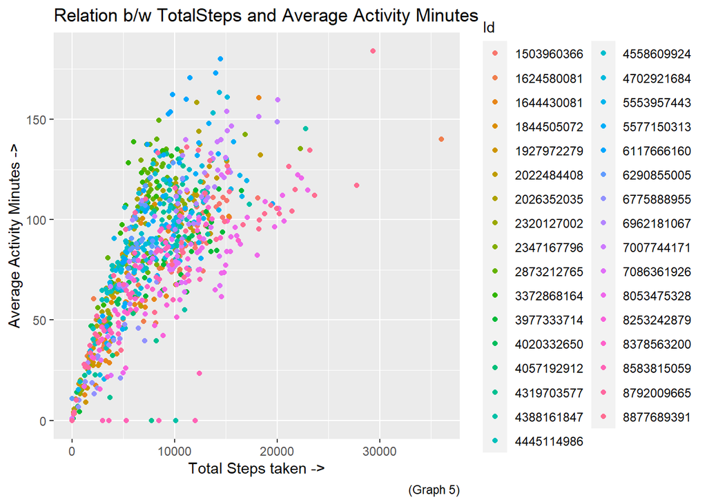

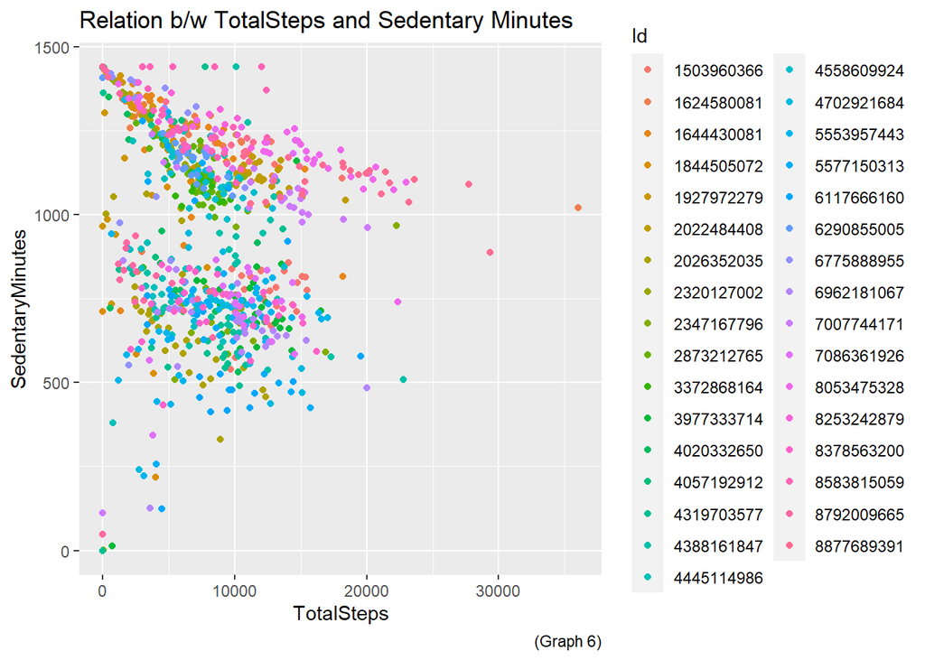

#### **CONCLUSION FROM GRAPH 5**

- The Relationship between steps and Average Activity minutes shows the increasing trend.
- More steps are counted as the activity minutes are increased.
- Average Activity minutes is the average of the following:
  - VeryActiveMinutes
  - FairlyActiveMinutes
  - LightlyActiveMinutes

#### **CONCLUSION FROM GRAPH 6**

- The Steps and Sedentary Minutes seems to have decreasing trend relation.

## —————————————————————————————–

### RELATION BETWEEN THE AVERAGE ACTIVITY MINUTES AND AVERAGE DISTANCE INTENSITY

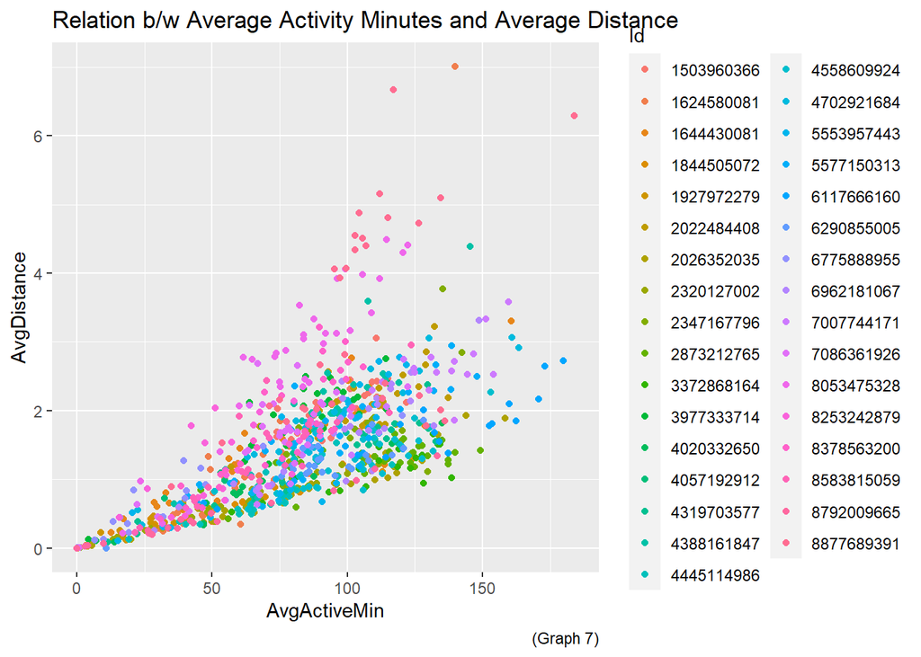

#### **CONCLUSION FROM GRAPH 7**

- The Graph shows the increasing trend.
- It concludes that the more is the distance covered more is the activity done.

## —————————————————————————————–

### RELATION BETWEEN THE CALORIES BURNT AND SLEEP

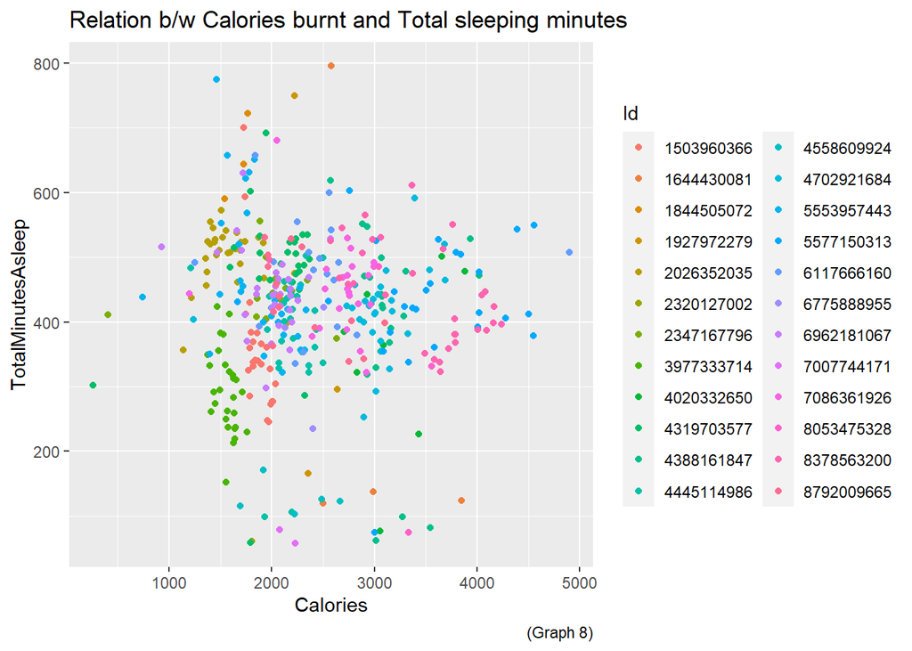

#### **CONCLUSION FROM GRAPH 8**

- The Graph shows the scattered trend.
- To identify the actual trend individual user has to be identified.

## —————————————————————————————–

### RELATION BETWEEN THE TOTAL STEPS AND SLEEP

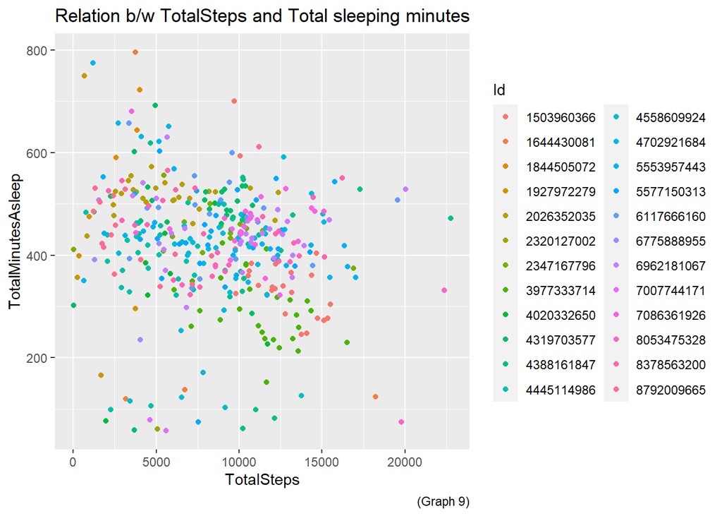

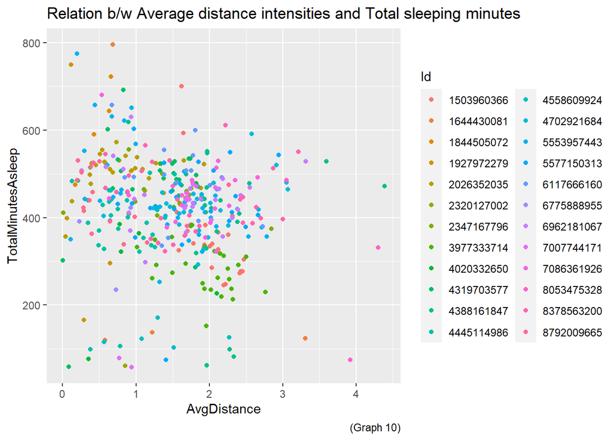

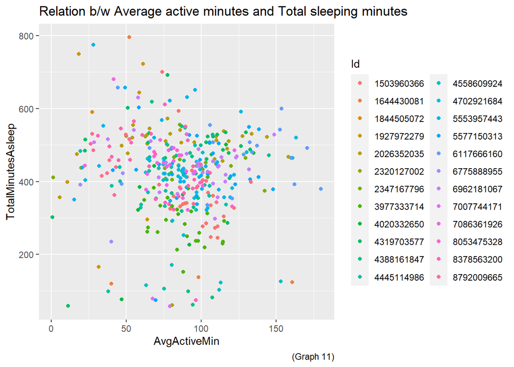

#### **CONCLUSION FROM GRAPH 9, GRAPH 10 AND GRAPH 11**

- The Relationship between Distance and sleep is scattered.
- Trend for an individual may be identified one at a time to find the relation.
- The Average disance is the average of the following distances :
  - Very Active
  - Moderately Active
  - Lightly Active
- Average Activity minutes is the average of the following:
  - VeryActiveMinutes
  - FairlyActiveMinutes
  - LightlyActiveMinutes

## —————————————————————————————–

### RELATION BETWEEN THE TOTAL STEPS AND HEARTRATE

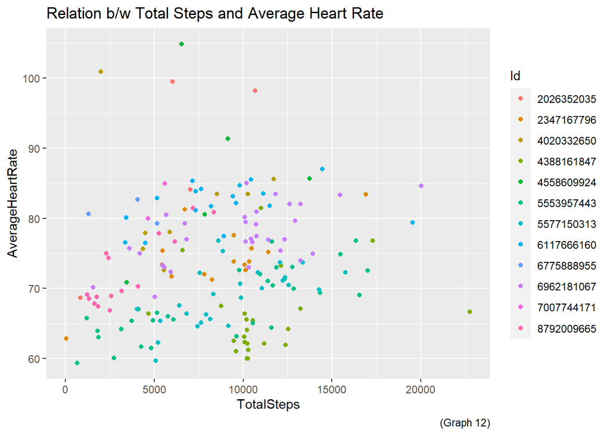

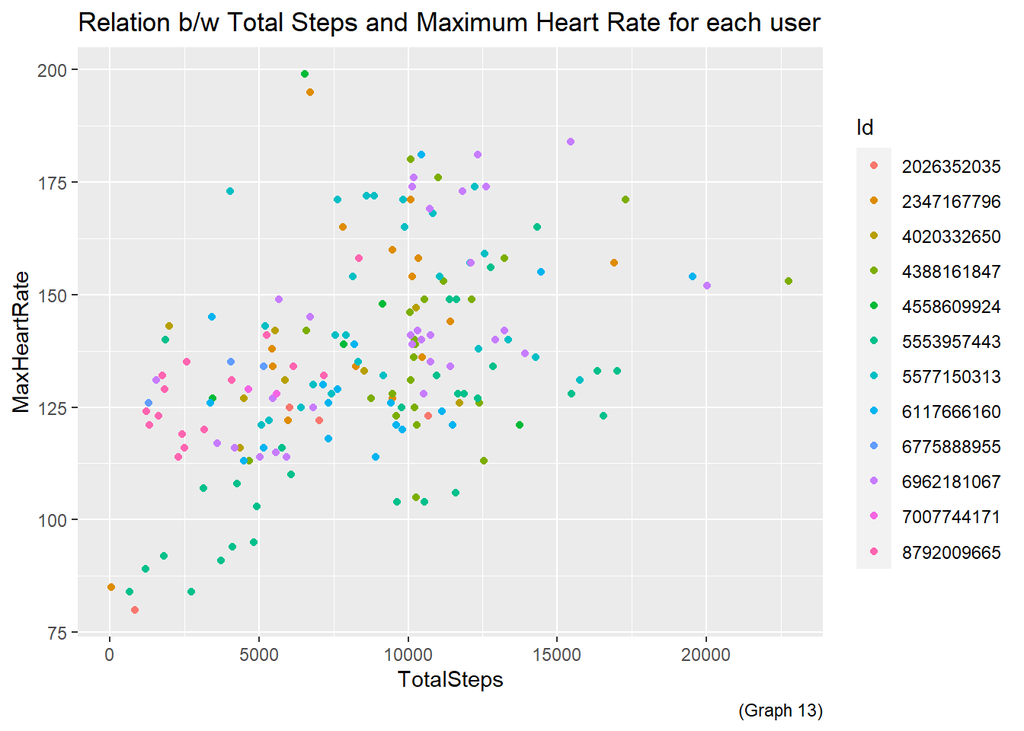

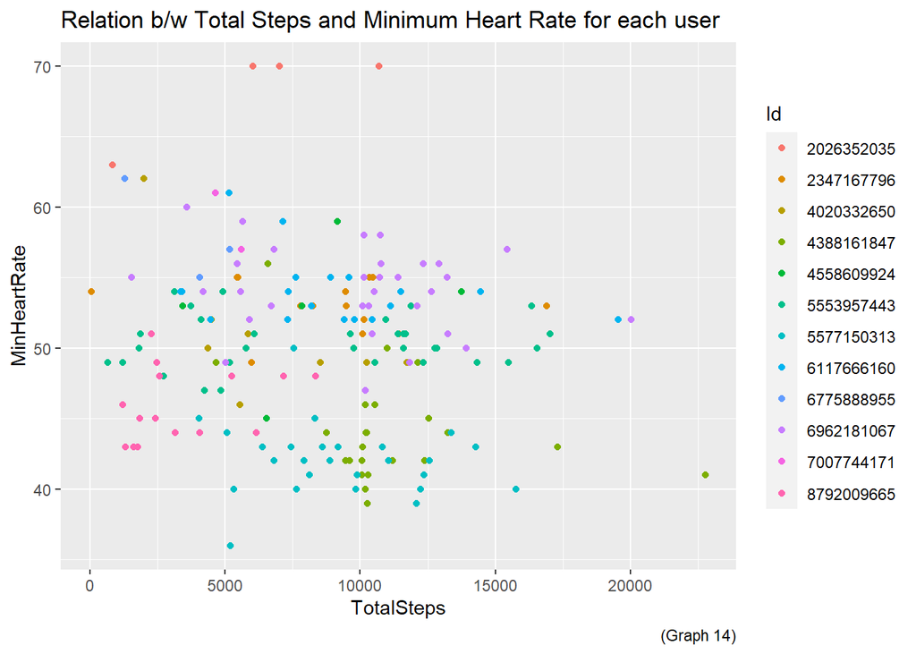

#### **CONCLUSION FROM GRAPH 12, GRAPH 13 AND GRAPH 14**

- Trend for an individual may be identified one at a time to find the relation between steps and heart rate.
- Also,more detailed data about the heart rate is needed to understand the trend

## —————————————————————————————–

### RELATION BETWEEN THE AVERAGE ACTIVITY MINUTES AND HEARTRATE

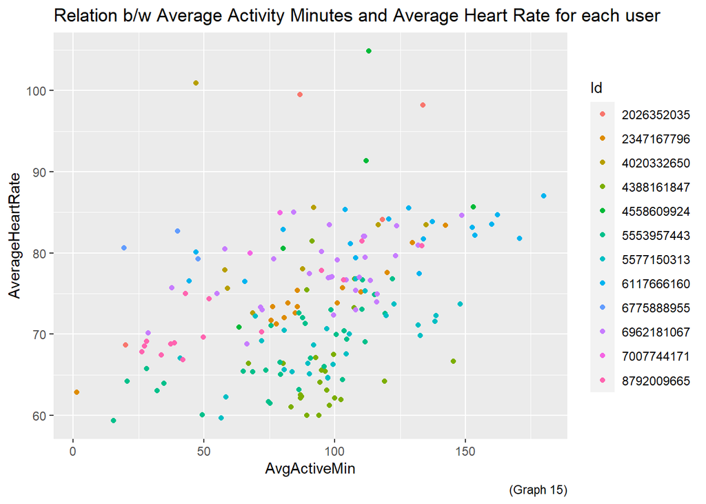

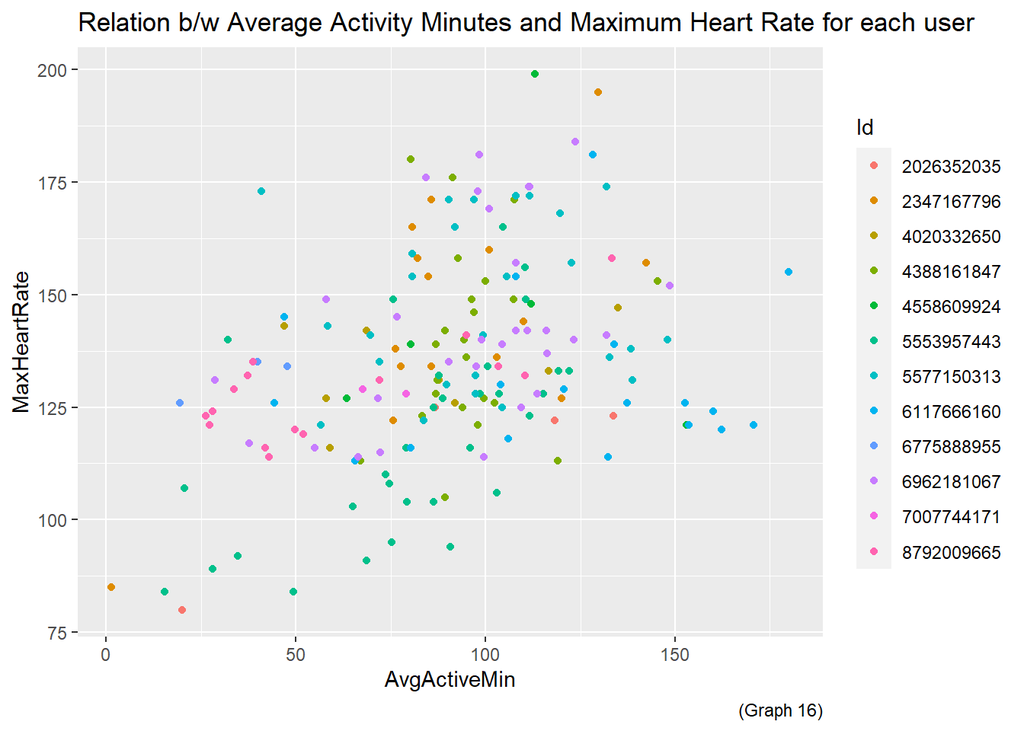

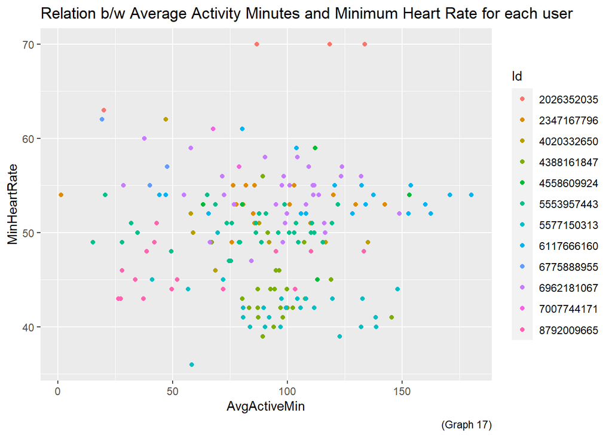

#### **CONCLUSION FROM GRAPH 15, GRAPH 16 AND GRAPH 17**

- To understand the relation between the heart rate and activity minutes the minimum and maximum heartrate at the time of activity should be studied.

## —————————————————————————————–

### RELATION BETWEEN THE CALORIES AND HEARTRATE

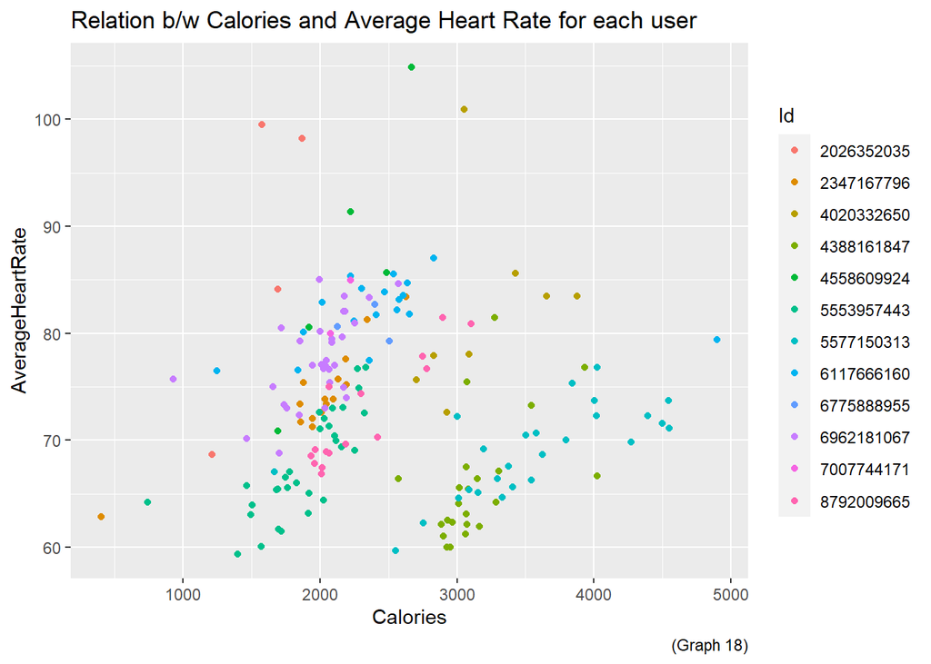

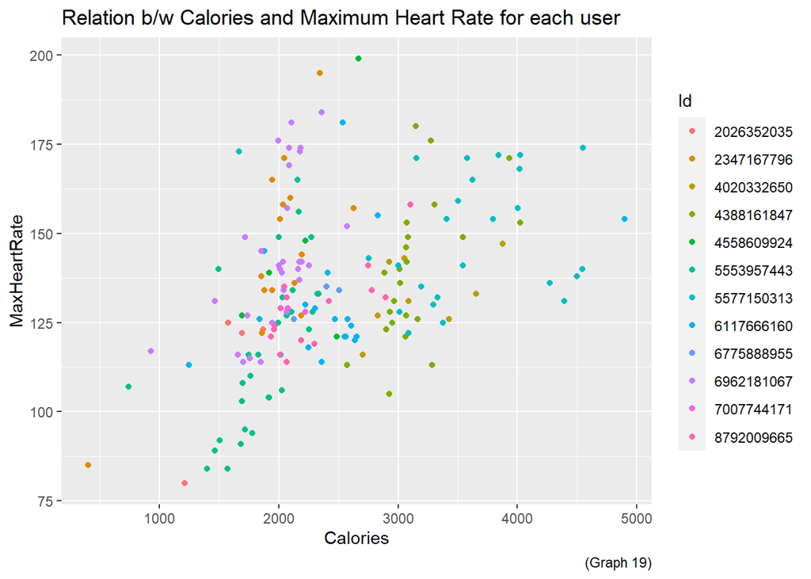

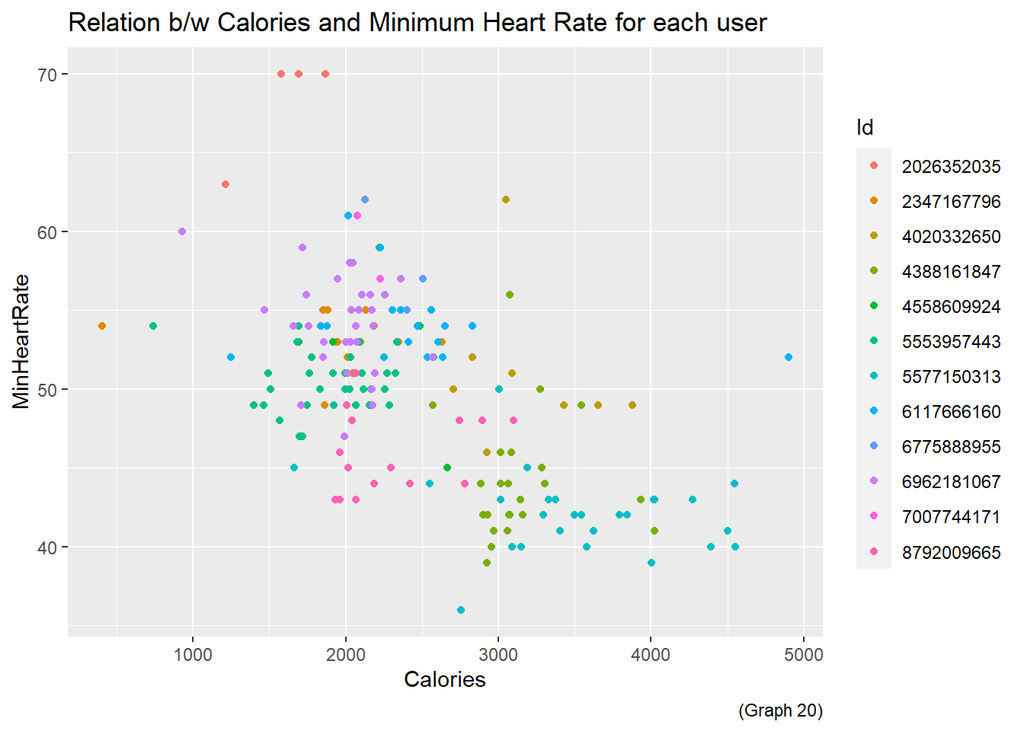

## —————————————————————————————–

### RELATION BETWEEN THE SLEEP AND HEARTRATE

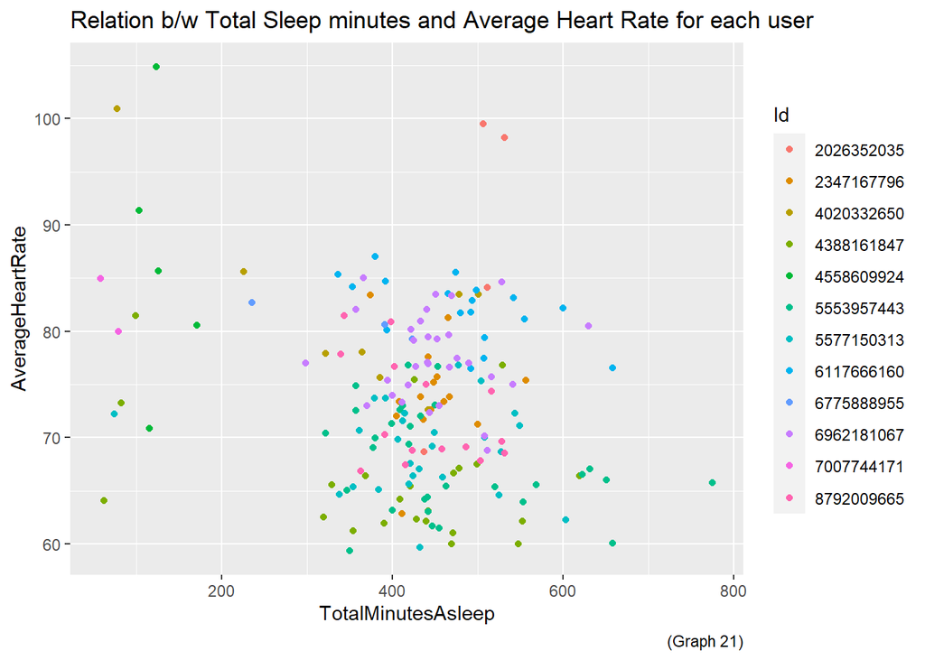

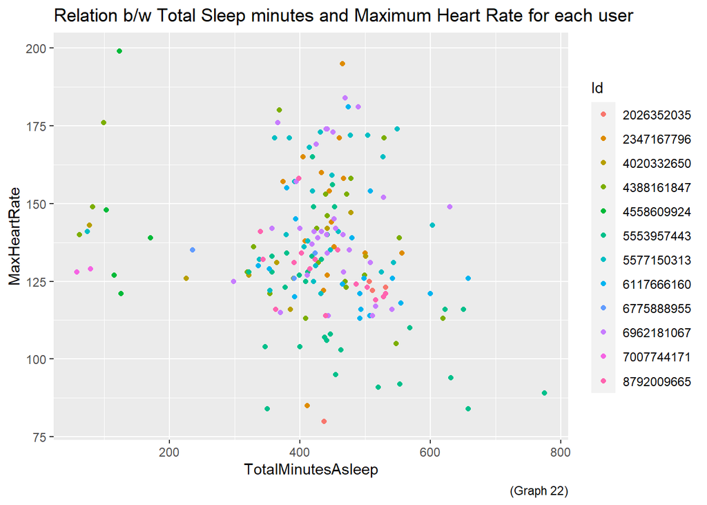

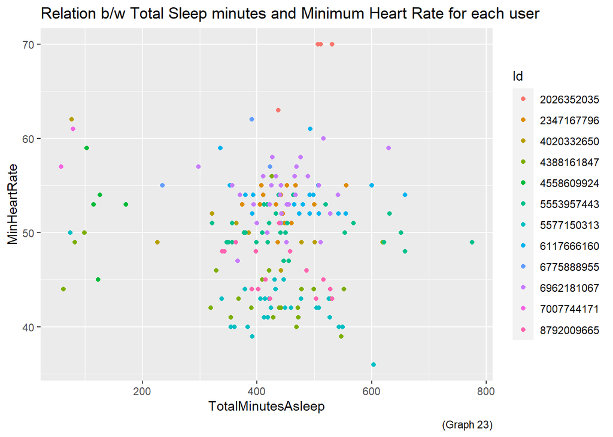

#### **CONCLUSION FROM GRAPH 21, GRAPH 22 AND GRAPH 23**

- More detailed data is needed about heartrate.

## —————————————————————————————–

### RELATION BETWEEN THE INDIVIDUAL’S AVERAGE HEARTRATE AND WEIGHT

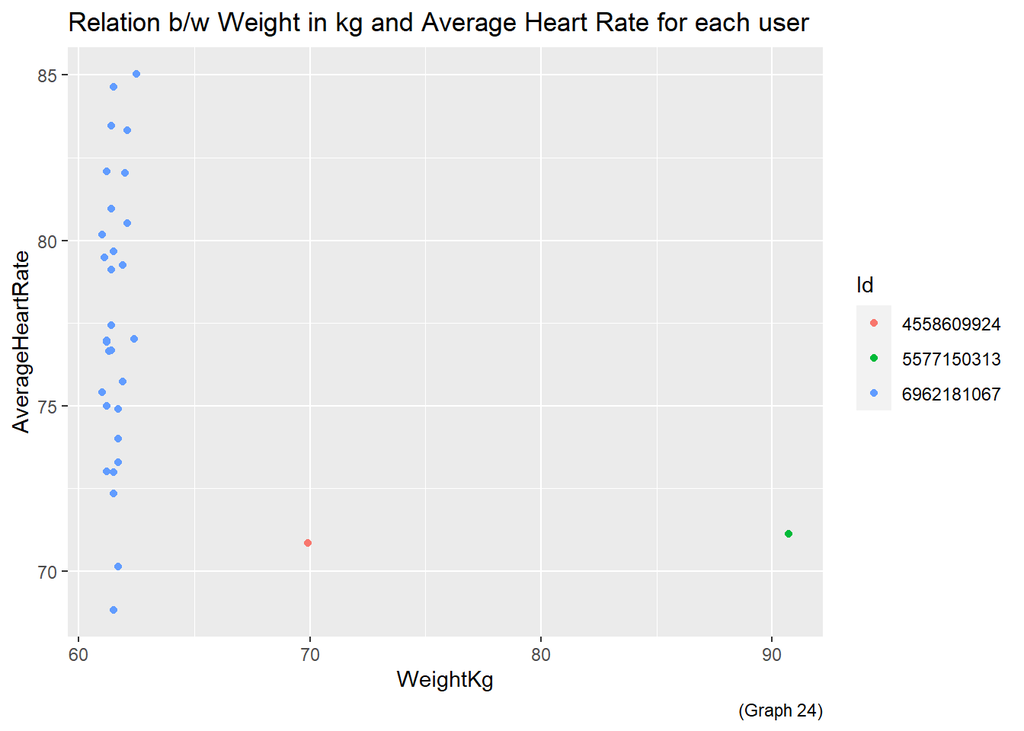

#### **CONCLUSION FROM GRAPH 24**

- More detailed data is needed about both heartrate and weight.

## —————————————————————————————–

### RELATION BETWEEN THE SLEEP AND WEIGHT

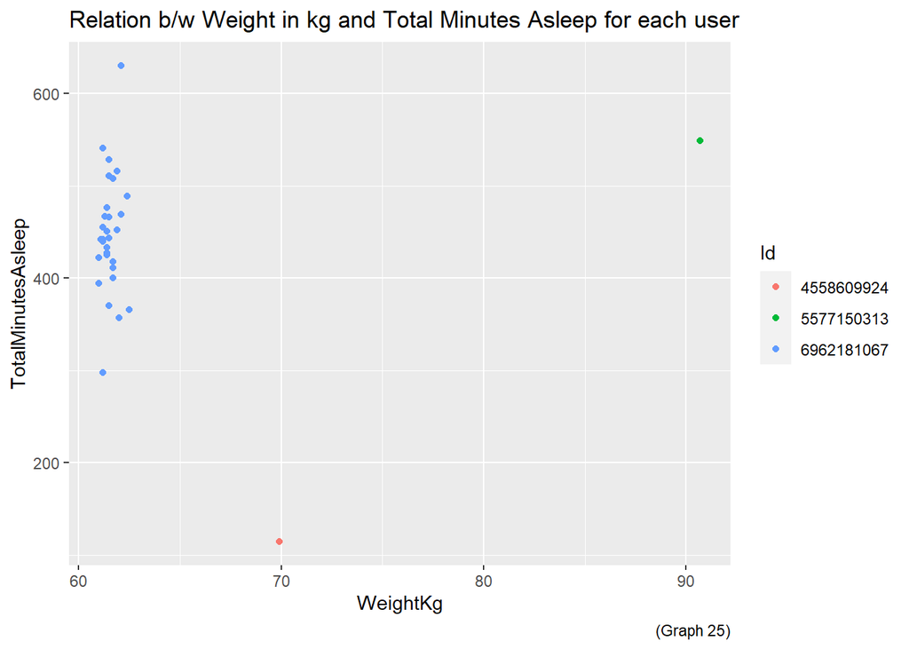

#### **CONCLUSION FROM GRAPH 25**

- More detailed data is needed about weight.

## —————————————————————————————–

### RELATION BETWEEN THE SLEEP AND BMI

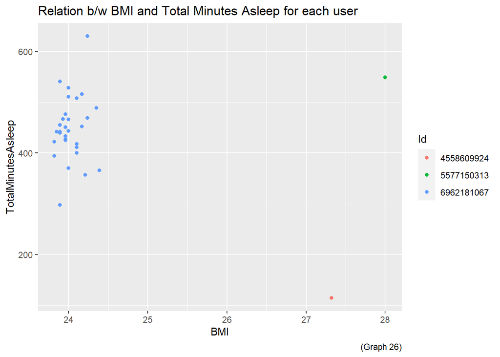

#### **CONCLUSION FROM GRAPH 26**

- More detailed data is needed about weight.

## —————————————————————————————–

#### **RECOMMENDATIONS**

- Heart rate details are logged for only few users. More details could be collected to understand the trend.
- Weight data is also limited. Features could be added to track Fat and body measurements on the smart device itself.
- Logging weight with selection on smart device itself could be easy for users to make manual entry rather than going into the application.
- Features to track water intake easily with just one press on device could be added

## —————————————————————————————–

## =======================================================================